```python
import numpy as np, pandas as pd, scipy.stats, sympy, matplotlib.pyplot as plt,matplotlib as mpl, math
from numpy import random_intel;from math import factorial
plt.rc('font', family='serif')
plt.rc('text', usetex=True)
mpl.rcParams['figure.dpi'] = 150
mpl.rcParams['savefig.dpi'] = 300;from IPython.display import display
```

# Exercise 1

Write a program generating 10.000 (pseudo-) random numbers and present these numbers in a histogramme

- First implement the LCG yourself by experimenting with different values of “a”, “b” and “c
- Evaluate the quality of the generators by graphical descriptive statistices (histogrammes, scatter plots) and statistical tests (χ2,Kolmogorov-Smirnov, run-tests, and correlation test.
- Then apply a system available generator (e.g. drand48() C, and C++) and perform the various statistical tests for this also.

First, the LCG is implemented and two series of random numbers are generated.

```python
# Defining LCG function
def LCG(x0,a,c,M,N):
    x = x0
    xarr = []
    U = []
    for i in range(N):
        x= (a*x+c)%M
        xarr.append(x)
        U.append(x/M)
    return U
```

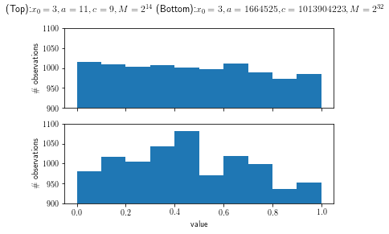

```python
n = 10;N=10000
fig,[ax1,ax2] = plt.subplots(2,sharex = True)
fig.suptitle("(Top):$x_0 = 3,a=11,c=9,M=2^{14}$ (Bottom):$x_0=3,a=1664525,c=1013904223,M=2^{32}$ ")

U1 = LCG(3,a=11,c=9,M=2**14,N=N) # LCG parameters 1
nobs1,w,patch =ax1.hist(U1,n)
ax1.set_ylim([900,1100])
ax1.set_ylabel("\# observations")

U2 = LCG(3,a=1664525,c=1013904223,M=2**32,N=N) # LCG parameters 2
nobs2,w,patch = ax2.hist(U2,n)
ax2.set_ylim([900,1100])
ax2.set_ylabel("\# observations")
ax2.set_xlabel("value")
plt.show()
```

At first glance, the histograms indicate very different performances, where the first one seems more uniformly distributed. Further investigation through scatter plots are done.

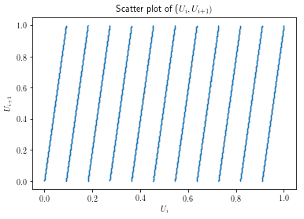

```
Figure 1: x_0=3, a=11, c=9, M=2^{14}
```

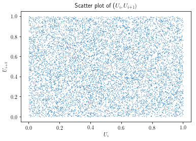

```
Figure 2: x_0=3, a=1664525, c=1013904223, M=2^{32}
```

```python
y1 = [U1[i+1] for i in range(N-1)]
plt.scatter(U1[:-1],y1,0.1)
plt.title("Scatter plot of ($U_i,U_{i+1})$")
plt.ylabel("$U_{i+1}$");plt.xlabel("$U_i$");plt.show()
print("Figure 1: x_0=3, a=11, c=9, M=2^{14} \n")

y2 = [U2[i+1] for i in range(N-1)]
plt.scatter(U2[:-1],y2,0.1)
plt.title("Scatter plot of ($U_i,U_{i+1})$")
plt.ylabel("$U_{i+1}$");plt.xlabel("$U_i$");plt.show()
print("Figure 2: x_0=3, a=1664525, c=1013904223, M=2^{32} \n")
```

Obviously, the parameters of the first "random" number generation are more correlated and clearly show a pattern, compared to the second random number generation. The first number generation can safely be discarded, and further statistical tests will be performed on the second one.

# χ2

The χ2 test will be performed over a series of 100 number generations. First T is calculated:

```
T_mean =  9.424119999999998
```

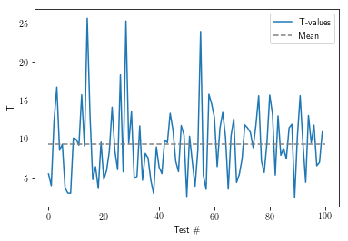

```python
Tarr = []
nobsArr = [] # For later use
Uarr = []
for i in range(100):
    U = LCG(i,a=1664525,c=1013904223,M=2**32,N=N)
    Uarr.append(U)
    nobs,_ = np.histogram(U,bins=10)
    nobsArr.append(nobs)
    Tarr.append(((nobs-N/n)**2/(N/n)).sum())
T = np.mean(Tarr)
print("T_mean = ",T)
plt.plot(Tarr, label="T-values")
plt.plot([0,100],[T,T],'--',c='gray', label="Mean")
plt.xlabel("Test \#");plt.ylabel("T");plt.legend();plt.show()
```

The above figure shows the T-value for each $\chi^2$-test. It is apparent, that few observations get high T-values, but the mean is located in the mass of the tests. Below, the $\chi^2$ distribution is plotted with the mean of the T-values. It is seen here, that the mean is well placed within the center of the distribution and within the critical values.

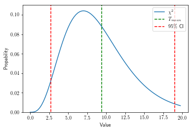

```python
scale = 4
plt.plot([i/scale for i in range(20*scale)],[scipy.stats.chi2.pdf(i/scale,df=n-1) for i in range(20*scale)],label = "$\chi^2 $")
plt.plot([T,T],[-1,1],'--g',label = "$T_{mean}$")
plt.plot([scipy.stats.chi2.ppf(0.975,df=9),scipy.stats.chi2.ppf(0.975,df=9)],[-1,1],'--r', label = "$95\%$ CI")
plt.plot([scipy.stats.chi2.ppf(0.025,df=9),scipy.stats.chi2.ppf(0.025,df=9)],[-1,1],'--r')
plt.ylim([0,0.11]); plt.ylabel("Propability"); plt.xlabel("Value"); plt.legend(); plt.show()
```

# Kolmogorov-Smirnov test

A distribution test is also performed over 100 different samples.

```
'$D_n$ = '
```

```
0.007080999999999996
```

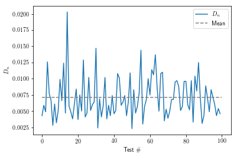

```python
#from sympy import *
D_nArr = []
for nobs in nobsArr:
    D = np.array([(nobs/N),(np.array([N/n for i in range(n)])/N)]).T.max(axis=1)
    D_nArr.append(max(abs((nobs/N).cumsum()-[0.1*i for i in range(1,11)])))
D_n = np.mean(D_nArr)
display("$D_n$ = ",D_n)
plt.plot(D_nArr, label="$D_n$")
plt.plot([0,100],[D_n,D_n],'--',c='gray', label="Mean")
plt.xlabel("Test \#"); plt.ylabel("$D_n$"); plt.legend(); plt.show()
```

The various values of D_n shows a similar pattern as seen in T-values of the $\chi^2$ tests. The empirical distribution and the hypothesized distribution are compared in the following.

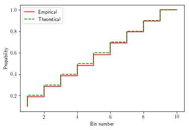

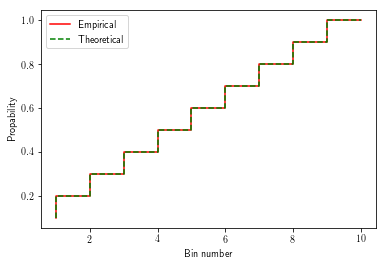

```python
index = np.argmax(D_nArr)
plt.plot([i for i in range(1,n+1)],(nobsArr[index]/N).cumsum(),'-r', drawstyle='steps',label = "Empirical")
plt.plot([i for i in range(1,n+1)],(np.array([N/n for i in range(n)])/N).cumsum(),'--g', drawstyle='steps',label = "Theoretical")
plt.xlabel("Bin number"); plt.ylabel("Propability"); plt.legend(); plt.show()

plt.plot([i for i in range(1,n+1)],(np.mean(nobsArr,axis=0)/N).cumsum(),'-r', drawstyle='steps',label = "Empirical")
plt.plot([i for i in range(1,n+1)],(np.array([N/n for i in range(n)])/N).cumsum(),'--g', drawstyle='steps',label = "Theoretical")
plt.xlabel("Bin number"); plt.ylabel("Propability"); plt.legend(); plt.show()
```

The two figures above show the step function found using cumulative sum against the expected theoretical. The top figure shows the worst case, based on the Kolmogorov-Smirnov test, where the bottom is the average performance of 100 iterations of the LCG. It is seen here that the average performance is almost identical to the theoretical and this fact will be further investigated numerically.

```python
All = ((n)**(1/2)+0.12+0.11/(n**(1/2)))*D_n
Norm = ((n)**(1/2)-0.1+0.85/(n**(1/2)))*D_n
exp = ((n)**(1/2)+0.26+0.5/(n**(1/2)))*(D_n-.2/n)
print(All,Norm,exp)
```

```
0.02348812108088046 0.023587315601142727 -0.046255078346301076
```

# Run test - Above/below

A run test is performed in order to find the fraction above or under the mean of the distribution

```python
n1Arr = []
n2Arr = []

for nobs in nobsArr:
    n1 = sum(nobs>nobs.mean())
    n2 = sum(nobs<nobs.mean())
    n1Arr.append(n1); n2Arr.append(n2)

n1 = np.mean(n1Arr)
n2 = np.mean(n2Arr)
mean, variance = 2*n1*n2/(n1+n2)+1,2*(n1*n1*(2*n1*n2-n1-n2))/((n1+n2)**2*(n1+n2-1))
Norm = scipy.stats.norm(mean, variance)
print("Mean:     ", mean,"\nVariance: ", variance)
```

```
Mean:      5.9438624873609704
Variance:  2.127706054029451
```

The mean of the number of runs in the test should thus be close to 6. That is, the number of times the value changes from above/below the median.

```python
nrunsArr = []
for nobs in nobsArr:
    count = nobs>nobs.mean()
    runs = [[]]
    k = 0
    for i,j in enumerate(count[:-1]):
        if j == count[i+1]:
            runs[k].append(i)
        else:
            runs[k].append(i)
            k = k + 1
            runs.append([])
    if count[-2]==count[-1]:
        runs[k].append(len(count)-1)
    else:
        runs.append(np.array([len(count)])-1)
    nrunsArr.append(len(runs))
nruns = np.mean(nrunsArr)
print(nruns)
```

```
6.31
```

Which is close to the expected mean. Below the number of runs for each run test performed is shown.

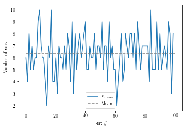

```
95% conf 9.44362751,
5% conf 2.44409747
Mean: 6.31000000
```

```python
def plotsN100(nruns,nrunsArr):
    plt.plot(nrunsArr,label = "$n_{runs}$")
    plt.plot([0,100],[nruns,nruns],"--",c="gray", label = "Mean")
    plt.ylabel("Number of runs");plt.xlabel("Test \#"); plt.legend()
    plt.show()
plotsN100(nruns,nrunsArr)
print("95% conf {:0.8f},\n5% conf {:0.8f}\nMean: {:0.8f}".format(Norm.ppf(0.95),Norm.ppf(0.05),nruns))
```

The mean along with the confidence intervals are plotted with the normal distribution below. Again, the mean is nicely placed in proximity of the theoretical mean.

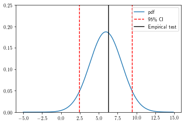

```python
plt.plot([i*0.1 for i in range(-50,150)],[Norm.pdf(i*0.1) for i in range(-50,150)],label = "pdf")
plt.plot([Norm.ppf(0.95),Norm.ppf(0.95)],[0,1],"--r",label = "95\% CI")
plt.plot([Norm.ppf(0.05),Norm.ppf(0.05)],[0,1],"--r")
plt.plot([nruns,nruns],[0,1],"k",label = "Empirical test")
plt.ylim([0,0.25])
plt.legend()
plt.show()
```

# Run test - Up and down

The next run test checks whether each consecutive observation increases or decreases in value.

```python
nrunsArr = []
binsArr = []
for U in Uarr:
    count = np.diff(U)>0
    runs = [[]]

    k = 0
    for i,j in enumerate(count[:-1]):
        if j == count[i+1]:
            runs[k].append(i)
        else:
            runs[k].append(i)
            k = k + 1
            runs.append([])
    if count[-2]==count[-1]:
        runs[k].append(len(count)-1)
    else:
        runs.append(np.array([len(count)])-1)
    nruns = len(runs)
    nrunsArr.append(nruns)
    runLen = [len(i) for i in runs]

    bins = np.zeros(6)

    for i in runLen:
        if i>=6:
            bins[5] += 1
        else:
            bins[i-1] += 1
    binsArr.append(bins)

bins = np.mean(binsArr,axis=0)
nruns = np.mean(nrunsArr)

print("Bins:           ", bins)
print("Number of runs: ", nruns)
```

```
Bins:            [4.16533e+03 1.82645e+03 5.31190e+02 1.16120e+02 2.05900e+01 3.79000e+00]
Number of runs:  6663.47
```

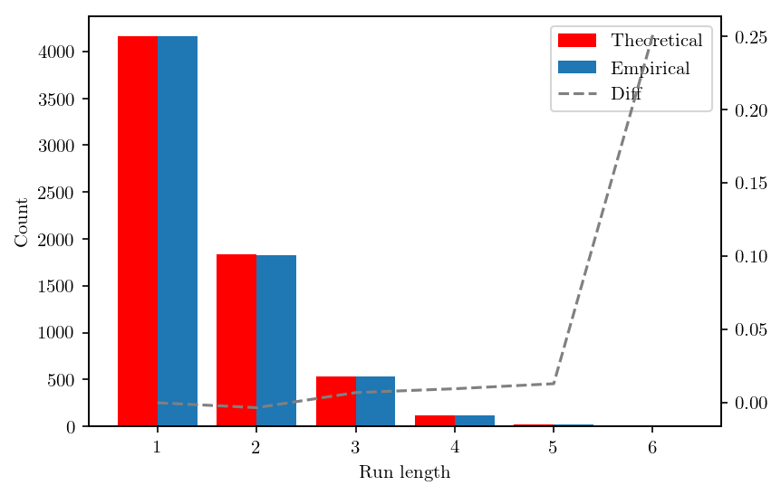

```python
fig, ax1= plt.subplots(1)
ax1.bar([i for i in range(1,len(R)+1)],R,color="r",align="edge",width=-0.4,label="Theoretical")
ax1.bar([i for i in range(1,len(bins)+1)],bins,align="edge",width=0.4,label="Empirical")
ax1.set_xlabel("Run length")
ax1.set_ylabel("Count")
ax2 = ax1.twinx()
ax2.plot([i for i in range(1,len(bins)+1)],(bins-R)/R,'--',color="grey",label = "Diff")
h1, l1 = ax1.get_legend_handles_labels()
h2, l2 = ax2.get_legend_handles_labels()
ax1.legend(h1+h2, l1+l2, loc='best')
plt.show()
```

Again, the number of runs for each test is plotted.

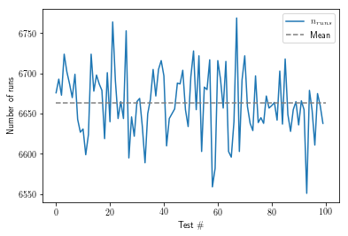

```python
plotsN100(nruns,nrunsArr)
```

The expected distribution of run lengths are calculated ([1, 2, 3, 4, 5, 6+]), as well as the expected total number of runs.

```python
R = []
for i in range(1,6+1):
    R.append((2*(i**2+3*i+1)*N - (i**3+3*i**2-i-4))/factorial(i+3))
CR = (2*N-1)/3
print("Expected distribution: ", R, "(sum = ", sum(R),")")
print("Expected total number of runs: ", CR)
```

```
Expected distribution:  [4166.708333333333, 1833.2166666666667, 527.7125, 115.05873015873016, 20.332564484126983, 3.0304398148148146] (sum =  6666.059234457671 )
Expected total number of runs:  6666.333333333333
```

Next, the empirical and theoretical distributions are compared in a histogram. The difference is seen to be fairly low when it comes to the short run lengths, but increases in the final run length (6+), as the relative difference is large.

```python
upS = []
length = 1
count = np.diff(U)>0
for i,j in enumerate(count[:-1]):
    if j!=count[i+1]:
        if j<count[i+1]:
            upS.append(length);
        length=1
    else:
        length+=1
upBins = np.zeros(6)

for i in upS:
    if i>=6:
        upBins[5] += 1
    else:
        upBins[i-1] += 1
#T = (bins-R)**2/(R)
#print(T.sum())
print("95% conf {:0.8f}, 5% conf {:0.8f}".format(scipy.stats.chi2.ppf(0.95,df=6),scipy.stats.chi2.ppf(0.05,df=6)))
```

```
95% conf 12.59158724, 5% conf 1.63538289
```

```python
print(upBins)
print(N*B)
```

```
[2062.  900.  287.   58.    8.    3.]
[[1666.66666667]
 [2083.33333333]
 [ 916.66666667]
 [ 263.88888889]
 [  57.53968254]
 [  11.9047619 ]]
```

```python
A= [[4529.4, 9044.9, 13568, 18091, 22615, 27892],
[9044.9,18097,27139,36187,45234,55789],
[13568,27139,40721,54281,67852,83685],
[18091,36187,54281,72414,90470,111580],
[22615,45234,67852,90470,113262,139476],
[27892,55789,83685,111580,139476,172860]]

B=np.array([[1/6,5/24,11/120,19/720,29/5040,1/840]]).T
Z = 1/(N-6)*(np.array([upBins]).T-N*B).T@A@(np.array([upBins]).T-N*B)
Z
```

```
array([[11255610.94433459]])
```

```python
test = []
length = 1
count = np.diff(U)>0
for i,j in enumerate(count[:-1]):
    if j<count[i+1]:
        test.append(length)
        length=1
    elif j!=count[i+1]:
        #test.append(length)
        length=1
    else:
        length+=1
```

```python
np.array([bins]).T-N*B
```

```
array([[2498.66333333],
       [-256.88333333],
       [-385.47666667],
       [-147.76888889],
       [ -36.94968254],
       [  -8.1147619 ]])
```

# Corr test

```python
Norm2 = scipy.stats.norm(0.25,7/(144*N))
N2 = 20000
U2 = LCG(i,a=1664525,c=1013904223,M=2**32,N=N2)
```

```python
c =[1/(N2-h)*sum([U2[i]*U2[i+h] for i in range(N2-h)]) for h in range(1,N2)]
```

```python
c =[1/(N-h)*sum([U[i]*U[i+h] for i in range(N-h)]) for h in range(1,N)]
```

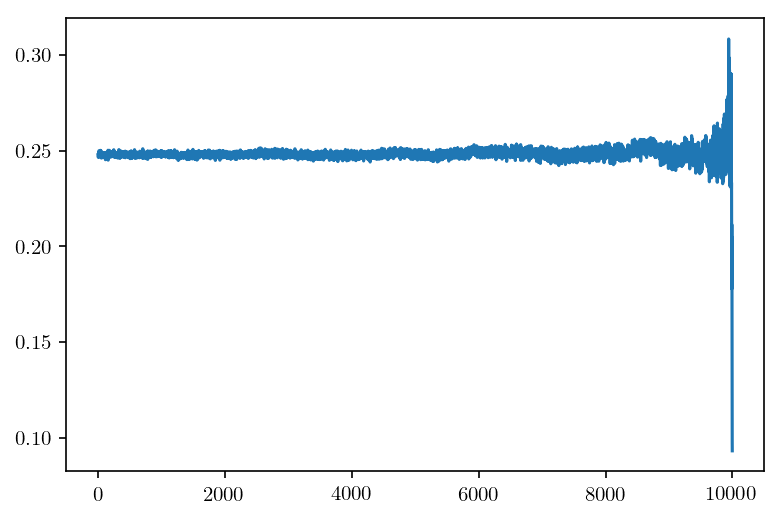

```python
plt.plot(c)
```

In the above plot, there are signs of increased correlation, when the iterations reach 10000.

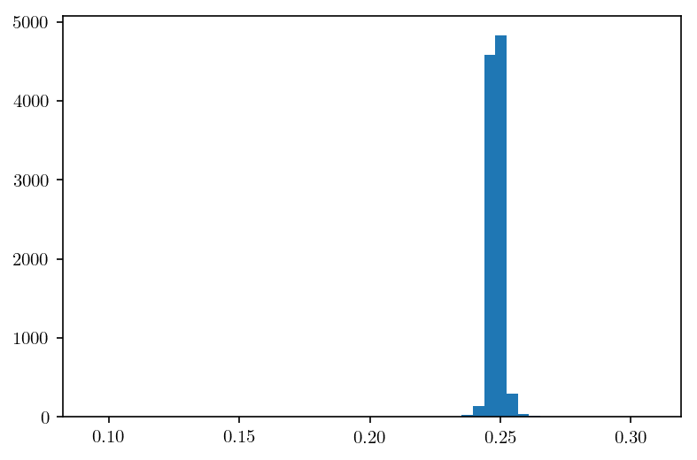

[figure not shown]

```python
box, w,t = plt.hist(np.array(c),50)
#plt.ylim([0,1])
plt.show()
x = np.linspace(0,0.5,1000)
plt.plot(x,scipy.stats.norm.pdf(x,0.25,7/(144*N)))
plt.show()
```

[output not shown]

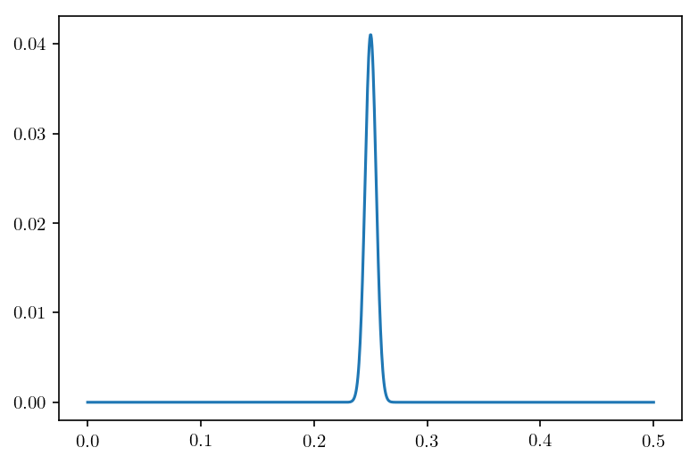

```python
plt.plot(x,scipy.stats.norm.pdf(x,0.25,7/(144*n))/sum(scipy.stats.norm.pdf(x,0.25,7/(144*n))))
X =[0.001*i for i in range(1000)]
plt.plot(X,np.array([f(i,sigmaEmp,muEmp) for i in X]))
#plt.plot(w[:-1],box/sum(box))
```

```python
plt.plot(X,np.array([f(i,sigmaEmp,muEmp) for i in X]))
sum(np.array([f(i,sigmaEmp,muEmp) for i in X]))
```

```python
sum(box/sum(box))
```

```python
X =[0.01*i for i in range(100)]
mu, s =0.25,7/(144*n)
from math import pi,exp
f = lambda x,s,mu: 1/(2*pi*s)**(1/2)*exp(-(1/2)*((x-mu)/(2*s))**2)
plt.plot(x,[f(i,s,mu) for i in x])
```

```python
X =[0.001*i for i in range(1000)]
muEmp= np.mean(c)
sigmaEmp = np.var(c)
plt.plot(X,np.array([f(i,s,mu) for i in X])/100)
plt.plot(X,np.array([f(i,sigmaEmp,muEmp) for i in X]))
```

```python
np.array(c)/N
```

```python
from numpy import random, random_intel

%timeit np.random.rand(10**5)


%timeit np.random_intel.rand(10**5)
```

# Comparison with system available generator

```python
np.random.seed(123)
U = np.random.rand(N)

fig,ax1 = plt.subplots(1)
#fig.suptitle("(Top):$x_0 = 3,a=11,c=9,M=2^{14}$ (Bottom):$x_0=3,a=1664525,c=1013904223,M=2^{32}$ ")

nobs,w,patch =ax1.hist(U,n)
ax1.set_ylim([900,1100])
ax1.set_ylabel("# observations")
plt.show()

y = [U[i+1] for i in range(len(U)-1)]

plt.scatter(U[:-1],y,0.1)
plt.title("Scatter plot of ($U_i,U_{i+1})$")
plt.ylabel("$U_{i+1}$")
plt.xlabel("$U_i$")
plt.show()
```

# $\chi^2$

```python
np.random.seed(123)
Tarr = []
nobsArr = [] # For later use
Uarr = []
for i in range(100):
    U = np.random.rand(N)
    Uarr.append(U)
    nobs,_ = np.histogram(U,bins=10)
    nobsArr.append(nobs)
    Tarr.append(((nobs-N/n)**2/(N/n)).sum())
T = np.mean(Tarr)
print("T_mean = ",T)
plt.plot(Tarr, label="T-values")
plt.plot([0,100],[T,T],'--',c='gray', label="Mean")
plt.xlabel("Test #")
plt.ylabel("T")
plt.legend()
plt.show()
```

```python
scale = 4
plt.plot([i/scale for i in range(20*scale)],[scipy.stats.chi2.pdf(i/scale,df=n-1) for i in range(20*scale)],label = "$\chi^2 $")
plt.plot([T,T],[-1,1],'--g',label = "$T_{mean}$")
plt.plot([scipy.stats.chi2.ppf(0.975,df=9),scipy.stats.chi2.ppf(0.975,df=9)],[-1,1],'--r', label = "$95\%$ CI")
plt.plot([scipy.stats.chi2.ppf(0.025,df=9),scipy.stats.chi2.ppf(0.025,df=9)],[-1,1],'--r')
plt.ylim([0,0.11])
plt.ylabel("Propability")
plt.xlabel("Value")
plt.legend()
plt.show()
```

# Kolmogorov-Smirnov test

A distribution test is also performed over 100 different samples.

```python
D_nArr = []
for nobs in nobsArr:
    D = np.array([(nobs/N),(np.array([N/n for i in range(n)])/N)]).T.max(axis=1)
    D_nArr.append(max(abs((nobs/N).cumsum()-[0.1*i for i in range(1,11)])))
D_n = np.mean(D_nArr)
print("D_n = ",D_n)
plt.plot(D_nArr, label="$D_n$")
plt.plot([0,100],[D_n,D_n],'--',c='gray', label="Mean")
plt.xlabel("Test #")
plt.ylabel("D_n")
plt.legend()
plt.show()
```

```python
index = np.argmax(D_nArr)
plt.plot([i for i in range(1,n+1)],(nobsArr[index]/N).cumsum(),'-r', drawstyle='steps',label = "Empirical")
plt.plot([i for i in range(1,n+1)],(np.array([N/n for i in range(n)])/N).cumsum(),'--g', drawstyle='steps',label = "Theoretical")

plt.xlabel("Bin number")
plt.ylabel("Propability")
plt.legend()
plt.show()

plt.plot([i for i in range(1,n+1)],(np.mean(nobsArr,axis=0)/N).cumsum(),'-r', drawstyle='steps',label = "Empirical")
plt.plot([i for i in range(1,n+1)],(np.array([N/n for i in range(n)])/N).cumsum(),'--g', drawstyle='steps',label = "Theoretical")
plt.xlabel("Bin number")
plt.ylabel("Propability")
plt.legend()
plt.show()
```

```python
All = ((n)**(1/2)+0.12+0.11/(n**(1/2)))*D_n
Norm = ((n)**(1/2)-0.1+0.85/(n**(1/2)))*D_n
exp = ((n)**(1/2)+0.26+0.5/(n**(1/2)))*(D_n-.2/n)
print(All,Norm,exp)
```

# Run test - Above/below

A run test is performed in order to find the fraction above or under the mean of the distribution

```python
n1Arr = []
n2Arr = []

for nobs in nobsArr:
    n1 = sum(nobs>nobs.mean())
    n2 = sum(nobs<nobs.mean())
    n1Arr.append(n1); n2Arr.append(n2)

n1 = np.mean(n1Arr)
n2 = np.mean(n2Arr)
mean, variance = 2*n1*n2/(n1+n2)+1,2*(n1*n1*(2*n1*n2-n1-n2))/((n1+n2)**2*(n1+n2-1))
Norm = scipy.stats.norm(mean, variance)
print("Mean:     ", mean,"\nVariance: ", variance)
```

```python
nrunsArr = []
for nobs in nobsArr:
    count = nobs>nobs.mean()
    runs = [[]]
    k = 0
    for i,j in enumerate(count[:-1]):
        if j == count[i+1]:
            runs[k].append(i)
        else:
            runs[k].append(i)
            k = k + 1
            runs.append([])
    if count[-2]==count[-1]:
        runs[k].append(len(count)-1)
    else:
        runs.append(np.array([len(count)])-1)
    nrunsArr.append(len(runs))
nruns = np.mean(nrunsArr)
print(nruns)
```

```python
plt.plot(nrunsArr,label = "$n_{runs}$")
plt.plot([0,100],[nruns,nruns],"--",c="gray", label = "Mean")
plt.ylabel("Number of runs")
plt.xlabel("Test #")
plt.legend()
plt.show()
print("95% conf {:0.8f},\n5% conf {:0.8f}\nMean: {:0.8f}".format(Norm.ppf(0.95),Norm.ppf(0.05),nruns))
```

```python
plt.plot([i*0.1 for i in range(-50,150)],[Norm.pdf(i*0.1) for i in range(-50,150)])
plt.plot([Norm.ppf(0.95),Norm.ppf(0.95)],[0,1],"--r")
plt.plot([Norm.ppf(0.05),Norm.ppf(0.05)],[0,1],"--r")
plt.plot([nruns,nruns],[0,1],"k")
plt.ylim([0,0.25])
plt.show()
```

# Run test - Up and down

The next run test checks whether each consecutive observation increases or decreases in value.

```python
nrunsArr = []
binsArr = []
for U in Uarr:
    count = np.diff(U)>0
    runs = [[]]
    k = 0
    for i,j in enumerate(count[:-1]):
        if j == count[i+1]:
            runs[k].append(i)
        else:
            runs[k].append(i)
            k = k + 1
            runs.append([])
    if count[-2]==count[-1]:
        runs[k].append(len(count)-1)
    else:
        runs.append(np.array([len(count)])-1)
    nruns = len(runs)
    nrunsArr.append(nruns)
    runLen = [len(i) for i in runs]

    bins = np.zeros(6)

    for i in runLen:
        if i>=6:
            bins[5] += 1
        else:
            bins[i-1] += 1
    binsArr.append(bins)

bins = np.mean(binsArr,axis=0)
nruns = np.mean(nrunsArr)

print("Bins:           ", bins)
print("Number of runs: ", nruns)
```

```python
plt.plot(nrunsArr,label = "$n_{runs}$")
plt.plot([0,100],[nruns,nruns],"--",c="gray", label = "Mean")
plt.ylabel("Number of runs")
plt.xlabel("Test #")
plt.legend()
plt.show()
```

```python
R = []
for i in range(1,6+1):
    R.append((2*(i**2+3*i+1)*N - (i**3+3*i**2-i-4))/factorial(i+3))

CR = (2*N-1)/3

print("Expected distribution: ", R, "(sum = ", sum(R),")")
print("Expected total number of runs: ", CR)
```

```python
fig, ax1= plt.subplots(1)
ax1.bar([i for i in range(1,len(R)+1)],R,color="r",align="edge",width=-0.4,label="Theoretical")
ax1.bar([i for i in range(1,len(bins)+1)],bins,align="edge",width=0.4,label="Empirical")
ax1.set_xlabel("Run length")
ax1.set_ylabel("Count")
ax2 = ax1.twinx()
ax2.plot([i for i in range(1,len(bins)+1)],(bins-R)/R,'--',color="grey",label = "Diff")
h1, l1 = ax1.get_legend_handles_labels()
h2, l2 = ax2.get_legend_handles_labels()
ax1.legend(h1+h2, l1+l2, loc='best')
plt.show()
```

```python
T = (bins-R)**2/(R)

print(T.sum())
print("95% conf {:0.8f}, 5% conf {:0.8f}".format(scipy.stats.chi2.ppf(0.95,df=len(bins)),scipy.stats.chi2.ppf(0.05,df=len(bins))))
```

```python
Z = 1/(N-6)*(np.array([bins]).T-N*B).T@A@(np.array([bins]).T-N*B)
Z
```